# **eyetools**

## A set of tools for eye data processing, analysis and visualisation in R

**eyetools** is a package that provides a set of simple tools that will facilitate common steps in the processing and analysis of eye data. It is intended for use with data from psychological experiments. The idea is to have a workflow which is aided by these functions, going from processing of the raw data, to extraction of event related data (i.e., fixations, saccades), to summarising those data at the trial level (e.g., time on areas of interest).

## How to use eyetools

### Installation

You can install eyetools using the following code:

```r
if (!require(devtools)) {
  install.packages("devtools")
  library(devtools)
}
install_github("tombeesley/eyetools")
```

and then load it:

```r
library(eyetools)
```

### The format of raw data

Data needs to be in a particular format to be compatible with the functions in eyetools. This format is 4 columns of data, with each row representing a sample. The four columns are: time, x, y, and trial. You can see an example with the built in data sets:

```r
example_raw_sac
```

```
## # A tibble: 32,608 × 4
##     time     x     y trial
##    <dbl> <dbl> <dbl> <dbl>
##  1     0  940.  535.     1
##  2     3  940.  536.     1
##  3     7  936.  533.     1
##  4    10  939.  536.     1
##  5    13  944.  533.     1
##  6    17  939.  535.     1
##  7    20  938.  531.     1
##  8    23  939.  536.     1
##  9    27  940.  534.     1
## 10    30  942.  537.     1
## # … with 32,598 more rows
```

### Repairing data

```r
raw_data <- eyetools::interpolate(example_raw_sac) # interpolated data
smooth_data <- eyetools::smoother(example_raw_sac) # smoothed data
```

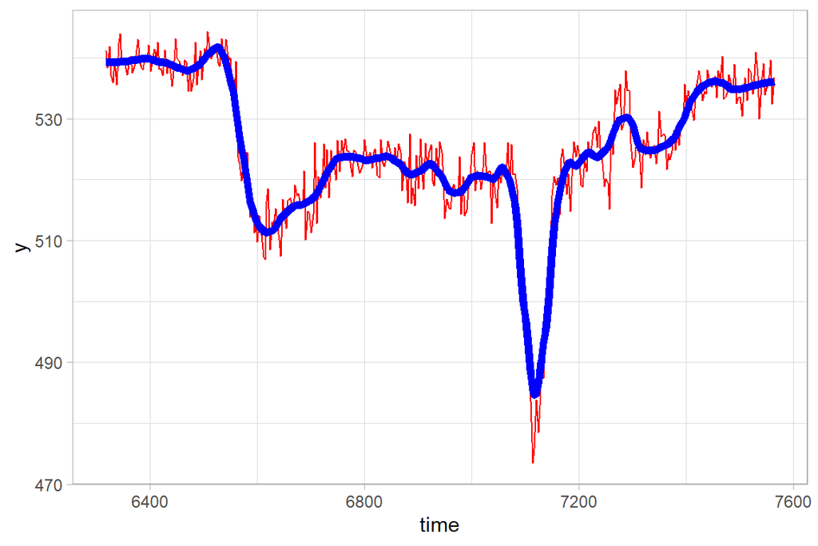

```r
library(tidyverse)

r <- filter(raw_data, trial == 2)
s <- filter(smooth_data, trial == 2)

ggplot() +
  geom_line(data = r,
            aes(x = time, y = y),
            colour = "red") +
  geom_line(data = s,
            aes(x = time, y = y),
            colour = "blue",
            size = 2)
```

### Processing fixations

The function `fix_dispersion()`, based on Salvucci and Goldberg (2000), will return a data frame with the fixations ordered by trial and by fixation sequence:

```r
raw_data_f <- filter(raw_data, trial <= 2) # get a sample of trials

fix_dispersion(raw_data_f, min_dur = 120, disp_tol = 100) # can set min duration and maximum dispersion of samples
```

```
##    trial fix_n start  end duration    x   y prop_NA min_dur disp_tol
## 1      1     1     0  230      230  937 535   0.000     120      100
## 2      1     2   273  460      187  170 500   0.000     120      100
## 3      1     3   643 1180      537 1743 534   0.000     120      100
## 4      1     4  1306 1426      120  252 503   0.243     120      100
## 5      1     5  1536 1656      120  131 530   0.243     120      100
## 6      1     6  1660 1816      156  135 533   0.000     120      100
## 7      2     1     0  230      230  938 539   0.000     120      100
## 8      2     2   273  407      134  201 515   0.000     120      100
## 9      2     3   410  767      357  143 522   0.000     120      100
## 10     2     4   940 1070      130 1696 527   0.000     120      100
## 11     2     5  1073 1247      174 1739 535   0.000     120      100
```

### Plotting data

The function `spatial_plot()` is a wrapper for a series of ggplot commands to plot both raw data and fixation summaries.

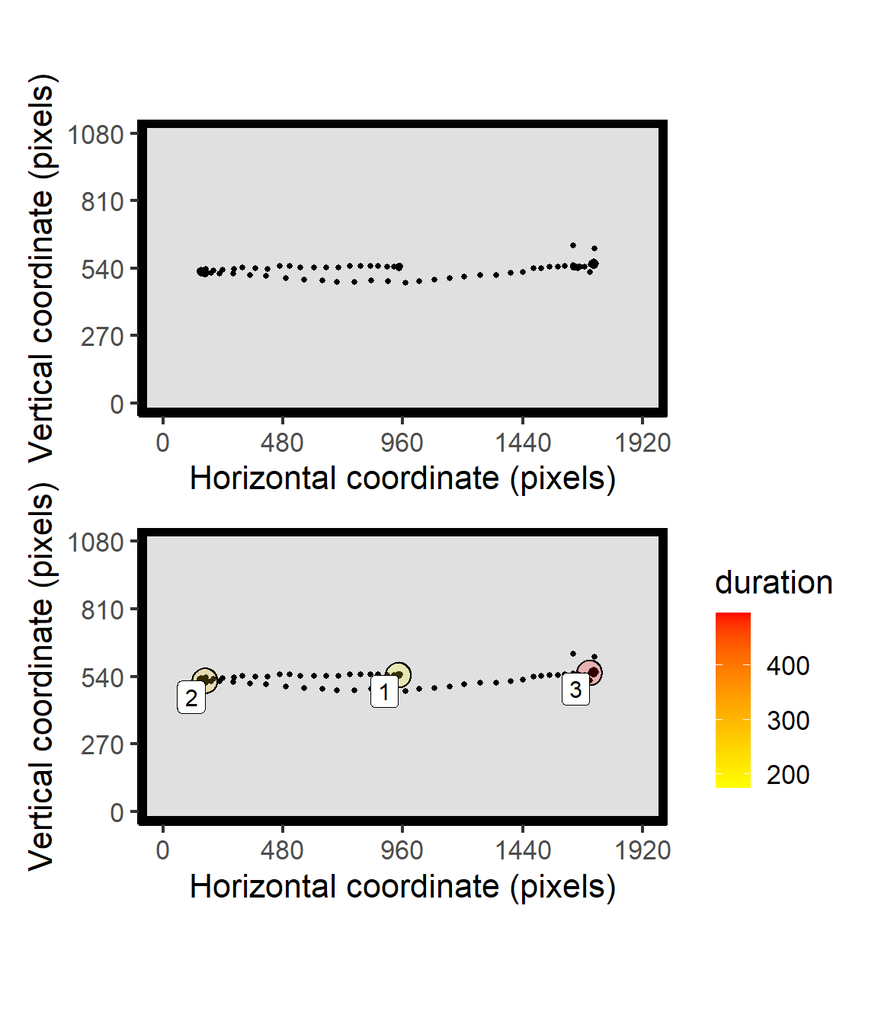

```r
library(patchwork) # patchwork plots adjacent figures

t_raw <- filter(example_raw_sac, trial == 9)

t_fix <- fix_dispersion(t_raw, disp_tol = 100, min_dur = 150) # process fixations

raw_plot <- spatial_plot(raw_data = t_raw, plot_header = FALSE)
fix_plot <- spatial_plot(raw_data = t_raw, fix_data = t_fix)

raw_plot/fix_plot # combined plot with patchwork
```

### Assessing time on areas of interest

`AOI_time()` will calculate the time spent on areas of interest. Areas of interest need to be defined by the x and y centre points, and the width and height in pixels:

```r
AOI_regions <- data.frame(matrix(nrow = 3, ncol = 4))
colnames(AOI_regions) <- c("x", "y", "width_radius", "height")

AOI_regions[1,] <- c(960, 540, 300, 300) # X, Y, W, H - square
AOI_regions[2,] <- c(200, 540, 300, 300) # X, Y, W, H - square
AOI_regions[3,] <- c(1720, 540, 300, 300) # X, Y, W, H - square
```

```r
t_raw <- filter(example_raw_sac, between(trial,1,5))

t_fix <- fix_dispersion(t_raw, disp_tol = 100, min_dur = 150) # process fixations

AOI_time(t_fix, AOIs = AOI_regions)
```

```
##   trial AOI_1 AOI_2 AOI_3
## 1     1   230   337   537
## 2     2   230   487   304
## 3     3   167   473   477
## 4     4   283   370   349
## 5     5   246   360   363
```

We can include the AOIs within our `spatial_plot()`:

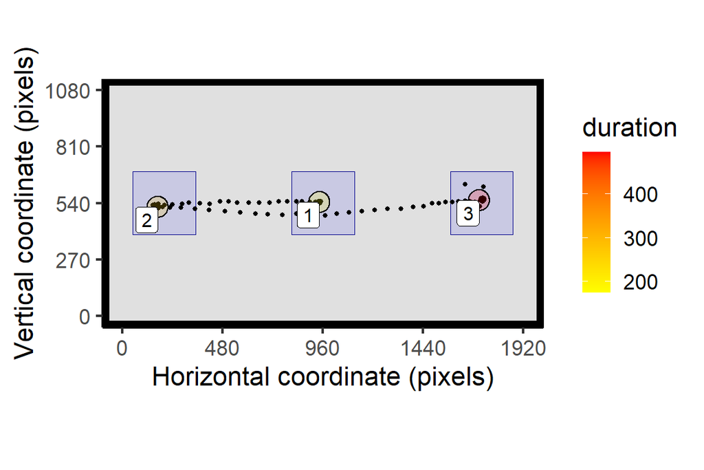

```r
t_raw <- filter(example_raw_sac, trial == 9) # single trial for plotting purposes

t_fix <- fix_dispersion(t_raw, disp_tol = 100) # process fixations

spatial_plot(raw_data = t_raw, fix_data = t_fix, AOIs = AOI_regions)
```

### Processing saccades

`VTI_saccade()` will process the data for saccades, based on a “velocity threshold identification” algorithm, as described in Salvucci and Goldberg (2000):

```r
t_raw <- filter(example_raw_sac, between(trial,7,9))

t_smooth <- smoother(t_raw)

VTI_saccade(t_smooth, sample_rate = 300)
```

[output not shown]

Saccadic eye movements can be plotted alongside other data using the `spatial_plot()` function:

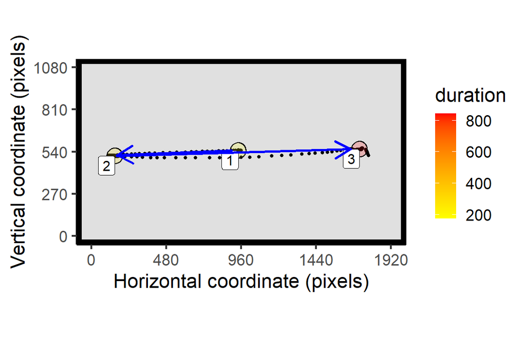

```r
t_smooth <- filter(t_smooth, trial == 8)

t_fix <- fix_dispersion(t_smooth, disp_tol = 100, min_dur = 150)

t_sac <- VTI_saccade(t_smooth, sample_rate = 300, threshold = 100)

spatial_plot(raw_data = t_smooth, fix_data = t_fix, sac_data = t_sac)
```